# SOS Biologiacal data visualisation: IL10

#load libraries: library(dplyr) library(tidyverse) library(ggplot2) library(“data.table”) library(stringr) library(“plyr”) library(ggpubr) library(DescTools) library(MESS)

First, we import the SOS_hormones_cleaned.csv file and remove participants who do not have IL10 data at all 4 time points.

```r
#import cleaned bioloigcal dataset:
setwd("~/Documents/8_Byrne_work/SOS_Bioloigical_data_cleaned")
SOS_IL10 <- read.csv('SOS_cytokines_cleaned.csv')
SOS_IL10$SampleID <- as.character(SOS_IL10$SampleID)

SOS_IL10 <- SOS_IL10[4:8]
SOS_IL10 <- (SOS_IL10 %>% arrange(SampleID,Time))

#Remove participants who do not have all 3 timepoints:
SOS_IL10_T1 = SOS_IL10 %>% filter(Time == "1")
SOS_IL10_T2 = SOS_IL10 %>% filter(Time == "2")
SOS_IL10_T3 = SOS_IL10 %>% filter(Time == "3")
SOS_IL10_T4 = SOS_IL10 %>% filter(Time == "4")

Merge1 <-merge(SOS_IL10_T1, SOS_IL10_T2, by = "SampleID", all = FALSE, all.x = TRUE)
Merge2 <-merge(Merge1, SOS_IL10_T3, by = "SampleID", all = FALSE, all.x = TRUE)
SOS_IL10_reshaped <-merge(Merge2, SOS_IL10_T4, by = "SampleID", all = FALSE, all.x = TRUE)
```

```
column names ‘Time.x’, ‘IL10_Ave.x’, ‘IL6_Ave.x’, ‘TNFalpha_Ave.x’, ‘Time.y’, ‘IL10_Ave.y’, ‘IL6_Ave.y’, ‘TNFalpha_Ave.y’ are duplicated in the result
```

```r
SOS_IL10_all_timepoints <- na.omit(SOS_IL10_reshaped)

#Merge to now include only the people who have all 4 timepoints:
SOS_IL10_final <- merge(SOS_IL10, SOS_IL10_all_timepoints, by = "SampleID", all = FALSE)
SOS_IL10_final <- SOS_IL10_final[1:5]
colnames(SOS_IL10_final) <- c("SampleID", "Time","IL10_Ave", "IL10_log", "IL10_nontran_win")
SOS_IL10_final <- (SOS_IL10_final %>% arrange(SampleID,Time))

#Clear variables no longer needed:
rm(SOS_IL10_T1, SOS_IL10_T2,SOS_IL10_T3,SOS_IL10_T4, Merge1, Merge2, SOS_IL10_reshaped, SOS_IL10_all_timepoints)

total <- unique(SOS_IL10$SampleID)
total_keep <- unique(SOS_IL10_final$SampleID)
perc_all_timepoints <- ((length(total_keep))/(length(total)))*100

perc_all_timepoints
```

```
[1] 85.89744
```

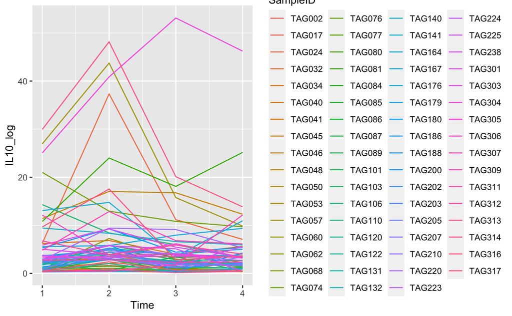

```r
All_participants_plot <- ggplot(SOS_IL10_final, aes(x = Time, y = IL10_log, group = SampleID, colour = SampleID)) +
                          geom_line()
All_participants_plot
```

```r
#Clear variables we no longer need:
rm(All_participants_plot)

# Identify where the maximum value is (T1-T4) and add as a variable to dataframe
PeakTime <- list()
PeakTime_id <- list()
Responders <- list()

for (i in unique(SOS_IL10_final$SampleID)) {
    idx <- which(SOS_IL10_final$SampleID==i, arr.ind=TRUE)
    #Get participants peak timepoint
    PeakTime[i] <- which.max(SOS_IL10_final$IL10_log[idx])
    #Get SampleID
    PeakTime_id[i] <- i
    #Using T1 > T2,T3,T4 as exclusion criteria, split group into "Responders" and "Not Responders"
      if (PeakTime[i] == "1"){
      Responders[i] <- "0"
      } else {
      Responders[i] <- "1"
      }
    }

PeakTime <- data.frame(PeakTime)
PeakTime <- t(PeakTime)
PeakTime <- data.frame(PeakTime)

PeakTime_id <- data.frame(PeakTime_id)
PeakTime_id <- t(PeakTime_id)
PeakTime_id <- data.frame(PeakTime_id)

Responders <- data.frame(Responders)
Responders <- t(Responders)
Responders <- data.frame(Responders)


Peak_time_all <- cbind(PeakTime, PeakTime_id, Responders)
#Clear variables no longer needed:
rm(PeakTime, PeakTime_id)

names(Peak_time_all)[1]<- "PeakTime"
names(Peak_time_all)[2]<- "SampleID"
names(Peak_time_all)[3]<- "Responders"

SOS_IL10_final <-merge(SOS_IL10_final, Peak_time_all, by = "SampleID", all = TRUE)
rm(Peak_time_all)
SOS_IL10_final$PeakTime <- as.factor(SOS_IL10_final$PeakTime)
```

We have split the data according to where the participant’s maximum IL10 (log) response occured; at time point 1, 2, 3 or 4. We can then plot the change over time, depending on the group variable “Peak Time”:

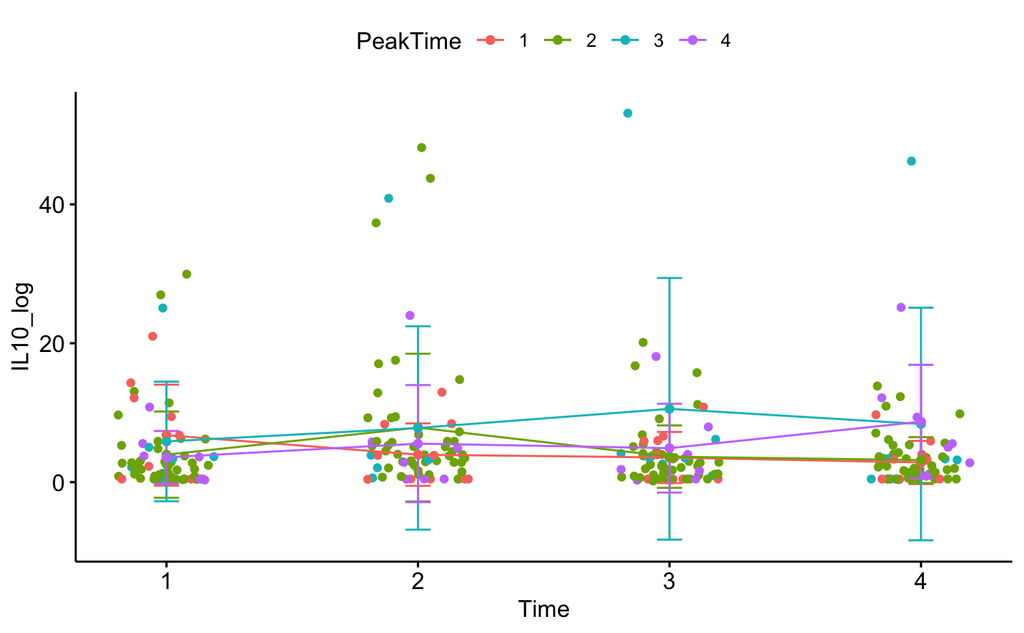

```r
Overall <- ggline(SOS_IL10_final, "Time", "IL10_log",
           group = "PeakTime",
           add = c("mean_sd", "jitter"),
           color = "PeakTime")
Overall
```

The number of subjects per “Peak Time” group:

```r
(summary(SOS_IL10_final$PeakTime)/4)
```

```
 1  2  3  4
10 43  7  7
```

```r
#Clear variable we no longer need:
rm(Overall)

#Divide participants by when their cortisol peak occured:
PeakTime1 <- SOS_IL10_final %>% filter(PeakTime == "1")
PeakTime2 <- SOS_IL10_final %>% filter(PeakTime == "2")
PeakTime3 <- SOS_IL10_final %>% filter(PeakTime == "3")
PeakTime4 <- SOS_IL10_final %>% filter(PeakTime == "4")
```

Now for more detail, within each “Peak time” group, we can see how individual subjects reacted:

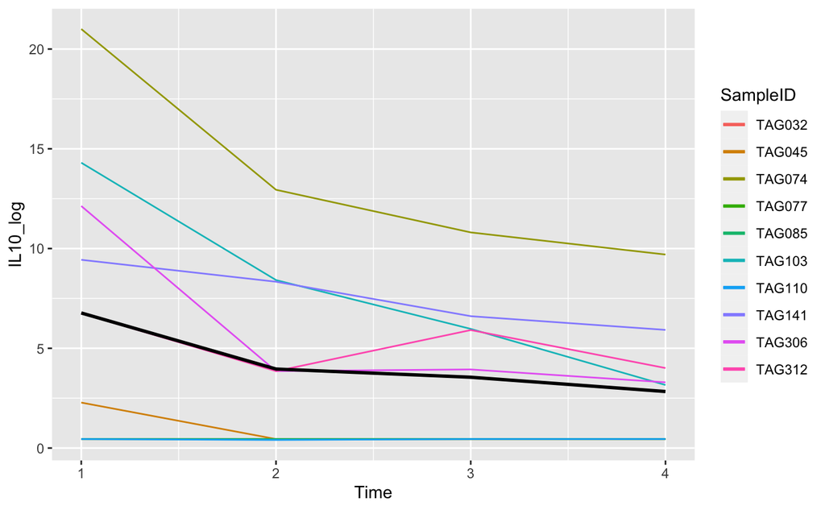

```r
PT1 <- ggplot(data = PeakTime1,aes(x = Time, y = IL10_log, group = SampleID, colour = SampleID)) +
       geom_line()+
       stat_summary(aes(group = 1), geom = "line", fun = mean, size = 1)

PT1
```

Descriptive stats of subjects whose response peaks at Timepoint 1

```r
summary(PeakTime1)
```

```
   SampleID              Time         IL10_Ave          IL10_log       IL10_nontran_win  PeakTime
 Length:40          Min.   :1.00   Min.   : 0.2837   Min.   : 0.4062   Min.   : 0.1321   1:40
 Class :character   1st Qu.:1.75   1st Qu.: 0.5500   1st Qu.: 0.4500   1st Qu.: 1.0902   2: 0
 Mode  :character   Median :2.50   Median : 2.8825   Median : 2.7209   Median : 4.8381   3: 0
                    Mean   :2.50   Mean   : 8.0320   Mean   : 4.2793   Mean   : 8.9462   4: 0
                    3rd Qu.:3.25   3rd Qu.:12.3903   3rd Qu.: 6.6477   3rd Qu.:13.4115
                    Max.   :4.00   Max.   :62.8067   Max.   :21.0044   Max.   :48.9823
 Responders
 0:40
 1: 0
```

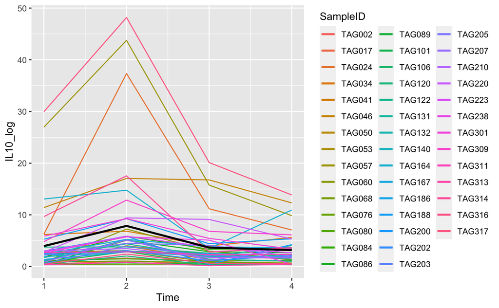

```r
PT2 <- ggplot(data = PeakTime2,aes(x = Time, y = IL10_log, group = SampleID, colour = SampleID)) +
      geom_line()+
      stat_summary(aes(group = 1), geom = "line", fun = mean, size = 1)
PT2
```

Descriptive stats of subjects whose response peaks at Timepoint 2

```r
summary(PeakTime2)
```

```
   SampleID              Time         IL10_Ave          IL10_log       IL10_nontran_win  PeakTime
 Length:172         Min.   :1.00   Min.   : 0.3458   Min.   : 0.1657   Min.   : 0.2152   1:  0
 Class :character   1st Qu.:1.75   1st Qu.: 3.0549   1st Qu.: 1.0627   1st Qu.: 4.6757   2:172
 Mode  :character   Median :2.50   Median : 5.5322   Median : 2.6597   Median : 7.8405   3:  0
                    Mean   :2.50   Mean   : 7.1774   Mean   : 4.6685   Mean   :11.3768   4:  0
                    3rd Qu.:3.25   3rd Qu.: 9.4334   3rd Qu.: 5.1514   3rd Qu.:12.0484
                    Max.   :4.00   Max.   :38.2278   Max.   :48.1763   Max.   :56.2580
 Responders
 0:  0
 1:172
```

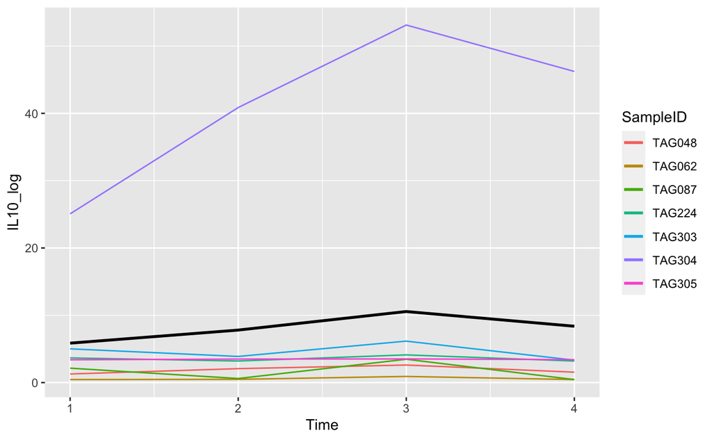

```r
PT3 <- ggplot(data = PeakTime3,aes(x = Time, y = IL10_log, group = SampleID, colour = SampleID)) +
      geom_line()+
     stat_summary(aes(group = 1), geom = "line", fun = mean, size = 1)
PT3
```

Descriptive stats of subjects whose response peaks at Timepoint 3

```r
summary(PeakTime3)
```

```
   SampleID              Time         IL10_Ave          IL10_log      IL10_nontran_win  PeakTime
 Length:28          Min.   :1.00   Min.   : 0.2837   Min.   : 0.450   Min.   :  1.904   1: 0
 Class :character   1st Qu.:1.75   1st Qu.: 1.7221   1st Qu.: 1.479   1st Qu.:  5.800   2: 0
 Mode  :character   Median :2.50   Median : 4.9374   Median : 3.360   Median :  6.952   3:28
                    Mean   :2.50   Mean   : 9.0008   Mean   : 8.149   Mean   : 23.204   4: 0
                    3rd Qu.:3.25   3rd Qu.:12.3277   3rd Qu.: 3.944   3rd Qu.: 11.056
                    Max.   :4.00   Max.   :38.3813   Max.   :53.126   Max.   :143.925
 Responders
 0: 0
 1:28
```

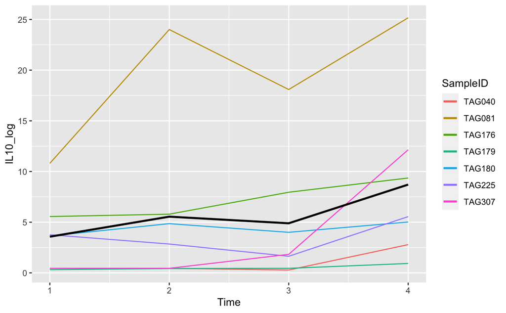

```r
PT4 <- ggplot(data = PeakTime4,aes(x = Time, y = IL10_log, group = SampleID, colour = SampleID)) +
        geom_line()+
        stat_summary(aes(group = 1), geom = "line", fun = mean, size = 1)
PT4
```

Descriptive stats of subjects whose response peaks at Timepoint 4

```r
summary(PeakTime4)
```

```
   SampleID              Time         IL10_Ave         IL10_log       IL10_nontran_win  PeakTime
 Length:28          Min.   :1.00   Min.   : 0.550   Min.   : 0.2828   Min.   : 0.6496   1: 0
 Class :character   1st Qu.:1.75   1st Qu.: 1.469   1st Qu.: 0.4500   1st Qu.: 6.0801   2: 0
 Mode  :character   Median :2.50   Median : 7.446   Median : 3.7025   Median : 8.9608   3: 0
                    Mean   :2.50   Mean   : 6.981   Mean   : 5.6793   Mean   :10.0426   4:28
                    3rd Qu.:3.25   3rd Qu.:11.852   3rd Qu.: 6.3328   3rd Qu.:12.3204
                    Max.   :4.00   Max.   :16.748   Max.   :25.1642   Max.   :33.0909
 Responders
 0: 0
 1:28
```

Some participants may be ‘non responders’, meaning they did not show a response to the task. If their peak response was at Timepoint 1, we have classified participants as ‘non responders’ (0). All other participants (who show peaks at Timepoints 2,3 or 4) are included as responders (1).

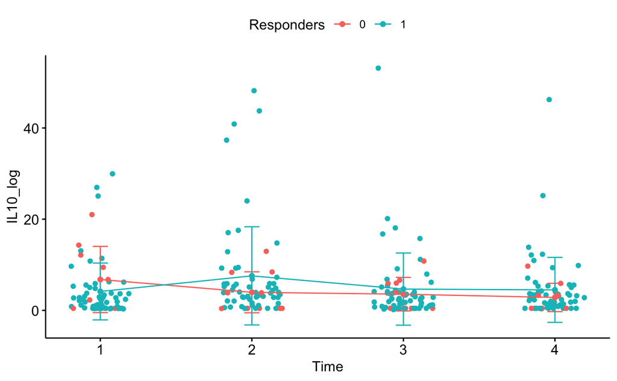

```r
#Clear variables no longer needed:
rm(PeakTime1, PT1,PeakTime2, PT2,PeakTime3, PT3, PeakTime4,PT4)

#Split group into "Responders" and "Not Responders"

RepondersvNoResponders_plot <-ggline(SOS_IL10_final, "Time", "IL10_log",
                               add = c("mean_sd", "jitter"),
                               color = "Responders")

RepondersvNoResponders_plot
```

The number of subjects Who are responders (1) and ‘non-responders’ (0)

```r
(summary(SOS_IL10_final$Responders)/4)
```

```
 0  1
10 57
```

```r
#Clear variable we no longer need:
rm(RepondersvNoResponders_plot)
```

We want to know whether responders (1) and ‘non-responders’ (0) showed a significantly different response at Timepoint 1:

```r
#Do a t-test to compare whether non-responders(0) had a higher T1 than responders(1)
Time_point_1 <- SOS_IL10_final[1:7]
Time_point_1 = Time_point_1 %>% filter(Time == "1")

compare_means(IL10_log ~ Responders, data = Time_point_1,
              method = "t.test")
```

| .y. | group1 | group2 | p | p.adj | p.format | p.signif | method |
| --- | --- | --- | --- | --- | --- | --- | --- |
| IL10_log | 0 | 1 | 0.3046101 | 0.3 | 0.3 | ns | T-test |

```r
rm(i, idx)

#For each subject, normalise time points 2,3 and 4, to timepoint 1.
Normalised_values <- list()
Normalise_id <- list()

for (i in as.character(SOS_IL10_final$SampleID)) {
  idx <- which(SOS_IL10_final$SampleID==i, arr.ind=TRUE)
  SampleID_current <- i
  baseline <- SOS_IL10_final$IL10_log[idx[1]]
    for (t in 1:4){
    Normalised_values[idx[t]] <- (SOS_IL10_final$IL10_log[idx[t]] - baseline)
    Normalise_id[idx[t]] <- SampleID_current
    }
}

#Reformat lists into data.frames
Normalised_values <- data.frame(Normalised_values)
Normalised_values <- t(Normalised_values)
Normalised_values <- data.frame(Normalised_values)

Normalise_id <- data.frame(Normalise_id)
Normalise_id <- t(Normalise_id)
Normalise_id <- data.frame(Normalise_id)
#Merge two data.frames
Normalised_all <- cbind(Normalised_values, Normalise_id)

#Clear variables no longer needed:
rm(Normalised_values, Normalise_id)

#Rename columns for merge (SampleID, also helps for checking that the rows have matched appropriately)
names(Normalised_all)[1]<- "BL_Norm_IL10_log"
names(Normalised_all)[2]<- "SampleID"

#Merge with SOS_Cortisol_final and remove unecessary extra SampleID column:
SOS_IL10_final <- cbind(SOS_IL10_final, Normalised_all)
SOS_IL10_final <- SOS_IL10_final[1:8]

#Clear variables no longer needed:
rm(Normalised_all, baseline, i, idx, SampleID_current, t)
```

Plot of change over time, depending on the group variable “Peak Time”:

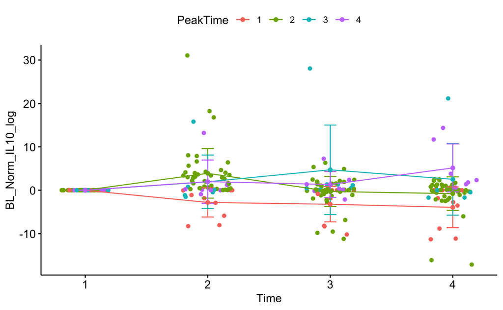

```r
Relative_to_baseline <- ggline(SOS_IL10_final, "Time", "BL_Norm_IL10_log",
           group = "PeakTime",
           add = c("mean_sd", "jitter"),
           color = "PeakTime")
Relative_to_baseline
```

Plot of change over time, depending on whether responders (1) and ‘non-responders’ (0)

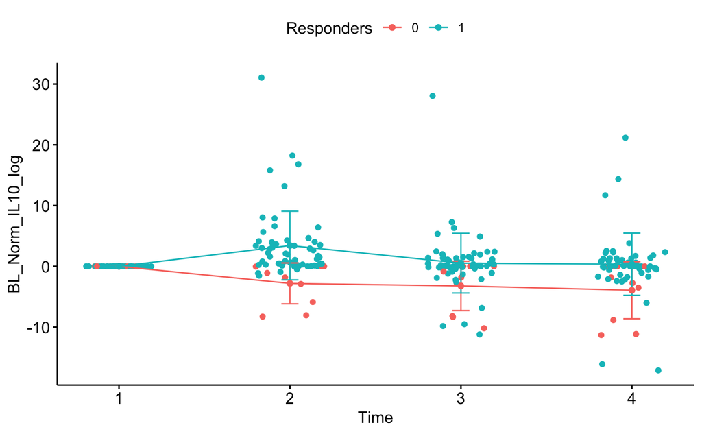

```r
Relative_to_baseline_resp <- ggline(SOS_IL10_final, "Time", "BL_Norm_IL10_log",
           group = "Responders",
           size = 0.5,
           add = c("mean_sd", "jitter"),
           color = "Responders")
Relative_to_baseline_resp
```

We want to know whether there are significant increases over time (relative to baseline)for responders (1):

```r
rm(Relative_to_baseline, Relative_to_baseline_resp)

#Do a t-test to compare whether non-responders(0) had a higher T1 than responders(1)
Responders <- SOS_IL10_final[1:8]
Responders = Responders %>% filter(Responders == 1)

compare_means(BL_Norm_IL10_log ~ Time, data = Responders,
              method = "anova")
```

| .y. | p | p.adj | p.format | p.signif | method |
| --- | --- | --- | --- | --- | --- |
| BL_Norm_IL10_log | 0.0001770906 | 0.00018 | 0.00018 | *** | Anova |

```r
NA
```

```r
#Follow up repeated measures t-tests
compare_means(BL_Norm_IL10_log ~ Time, data = Responders, paired = TRUE,
              method = "t.test")
```

| .y. | group1 | group2 | p | p.adj | p.format | p.signif | method |
| --- | --- | --- | --- | --- | --- | --- | --- |
| BL_Norm_IL10_log | 1 | 2 | 2.717861e-05 | 0.00016 | 2.7e-05 | **** | T-test |
| BL_Norm_IL10_log | 1 | 3 | 4.259578e-01 | 1.00000 | 0.4260 | ns | T-test |
| BL_Norm_IL10_log | 1 | 4 | 6.114525e-01 | 1.00000 | 0.6115 | ns | T-test |
| BL_Norm_IL10_log | 2 | 3 | 2.002045e-03 | 0.01000 | 0.0020 | ** | T-test |
| BL_Norm_IL10_log | 2 | 4 | 4.322936e-03 | 0.01700 | 0.0043 | ** | T-test |
| BL_Norm_IL10_log | 3 | 4 | 6.579868e-01 | 1.00000 | 0.6580 | ns | T-test |

```r
#Calculate the area under the curve for each responder:
AUC_list <- list()
AUC_id <- list()

for (i in unique(SOS_IL10_final$SampleID)) {
    idx <- which(SOS_IL10_final$SampleID==i, arr.ind=TRUE)
    #Get participants AUC for T1-4:
    AUC_list[i] <- auc(
                SOS_IL10_final$Time[idx],
                SOS_IL10_final$BL_Norm_IL10_log[idx],
                from = min(1, na.rm = TRUE),
                to = max(4, na.rm = TRUE),
                type = c("spline"),
                absolutearea = FALSE,
                subdivisions = 100,
                )
    #Get SampleID
    AUC_id[i] <- i
}
#Reformat lists into data.frames
AUC_list <- data.frame(AUC_list)
AUC_list <- t(AUC_list)
AUC_list <- data.frame(AUC_list)

AUC_id <- data.frame(AUC_id)
AUC_id <- t(AUC_id)
AUC_id <- data.frame(AUC_id)

#Merge two data.frames
AUC_all <- cbind(AUC_list, AUC_id)

#Clear variables no longer needed:
#rm(AUC_list, AUC_id)

#Rename columns for merge (SampleID, also helps for checking that the rows have matched appropriately)
names(AUC_all)[1]<- "AUC_BL_Norm_IL10_log"
names(AUC_all)[2]<- "SampleID"

#Merge with SOS_Cortisol_final and remove unecessary extra SampleID column:
SOS_IL10_final <-merge(SOS_IL10_final, AUC_all, by = "SampleID", all = TRUE)

#Clear variables no longer needed:
rm(AUC_all, i, idx)
#Update Responders dataframe to include AUC
Responders <- SOS_IL10_final[1:9]
Responders = Responders %>% filter(Responders == 1)
```

Plot AUC values:

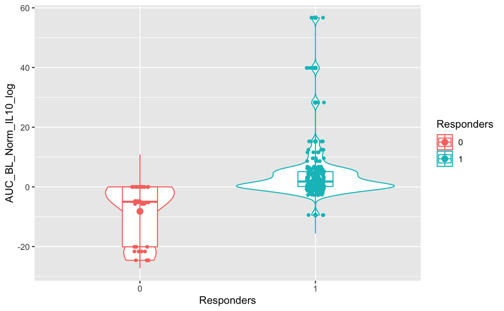

```r
#Plot AUC value for
AUC_plot <- ggplot(SOS_IL10_final, aes(Responders, AUC_BL_Norm_IL10_log, colour=Responders)) +
    geom_violin() +
    geom_boxplot(width=0.2, position = "dodge2") +
    stat_summary(fun.data=mean_sdl,
                 geom="pointrange") +
    geom_jitter(shape=16, position=position_jitter(0.05))

AUC_plot
```

```r
rm(AUC_plot)
```

We can see that the greatest change in IL10 level occurs between T1 and T2. We are therefore interested to quantify the magnitude of this change per participant. If participant’s change is +ve (meaning an increase from T1 –> T2) = 1. If participant’s change is -ve (meaning a decrease from T1 –> T2) = 0:

```r
T1T2_list <- list()
T1T2_id <- list()
T1T2_direction <- list()

for (i in as.character(SOS_IL10_final$SampleID)){
    idx <- which(SOS_IL10_final$SampleID==i, arr.ind=TRUE)
    T1T2_id[i] <-i
    T1T2_list[i] <-(SOS_IL10_final$IL10_log[idx[2]] - SOS_IL10_final$IL10_log[idx[1]])
     if (T1T2_list[i] > "0"){
      T1T2_direction[i] <- "1"
      } else {
      T1T2_direction[i] <- "0"
      }
    }

#Reformat lists into data.frames
T1T2_list <- data.frame(T1T2_list)
T1T2_list <- t(T1T2_list)
T1T2_list <- data.frame(T1T2_list)

T1T2_id <- data.frame(T1T2_id)
T1T2_id <- t(T1T2_id)
T1T2_id <- data.frame(T1T2_id)

T1T2_direction <- data.frame(T1T2_direction)
T1T2_direction <- t(T1T2_direction)
T1T2_direction <- data.frame(T1T2_direction)

#Merge two data.frames
T1T2_all <- cbind(T1T2_list, T1T2_id, T1T2_direction)

#Clear variables no longer needed:
rm(T1T2_list, T1T2_id, T1T2_direction)

#Rename columns for merge (SampleID, also helps for checking that the rows have matched appropriately)
names(T1T2_all)[1]<- "Change_T1_T2"
names(T1T2_all)[2]<- "SampleID"
names(T1T2_all)[3]<- "Change_T1_T2_Direction"

#Merge with SOS_IL10_final and remove unecessary extra SampleID column:
SOS_IL10_final <-merge(SOS_IL10_final, T1T2_all, by = "SampleID", all = TRUE)
rm(T1T2_all)

(summary(SOS_IL10_final$Change_T1_T2_Direction)/4)
```

```
 0  1
16 51
```

```r
SOS_IL10_final$Change_T1_T2_Direction <- as.factor(SOS_IL10_final$Change_T1_T2_Direction)
```

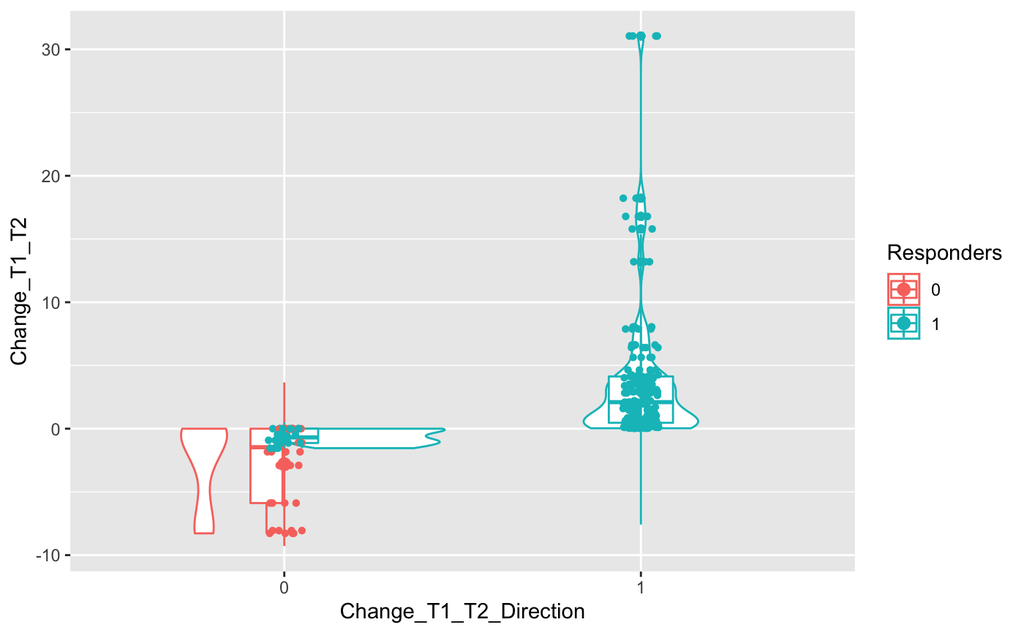

```r
ChangeT1T2 <- ggplot(SOS_IL10_final, aes(Change_T1_T2_Direction, Change_T1_T2, colour=Responders)) +
    geom_violin() +
    geom_boxplot(width=0.2, position = "dodge2") +
    stat_summary(fun.data=mean_sdl,
                 geom="pointrange") +
    geom_jitter(shape=16, position=position_jitter(0.05))

ChangeT1T2
```

How many people are responders who have a positive change:

```r
Resp_pos <- count(which(SOS_IL10_final$Responders == 1 & SOS_IL10_final$Change_T1_T2_Direction == 1))
(nrow(Resp_pos)/4)
```

```
[1] 51
```

How many people are responders who have a negative change:

```r
Resp_neg <- count(which(SOS_IL10_final$Responders == 1 & SOS_IL10_final$Change_T1_T2_Direction == 0))
(nrow(Resp_neg)/4)
```

```
[1] 6
```

How many people are non-responders who have a positive change:

```r
Non_resp_pos <- count(which(SOS_IL10_final$Responders == 0 & SOS_IL10_final$Change_T1_T2_Direction == 1))
(nrow(Non_resp_pos)/4)
```

```
[1] 0
```

How many people are non-responders who have a negative change:

```r
Non_resp_neg <- count(which(SOS_IL10_final$Responders == 0 & SOS_IL10_final$Change_T1_T2_Direction == 0))
(nrow(Non_resp_neg)/4)
```

```
[1] 10
```

```r
rm(Resp_pos, Resp_neg, Non_resp_pos, Non_resp_neg)
```

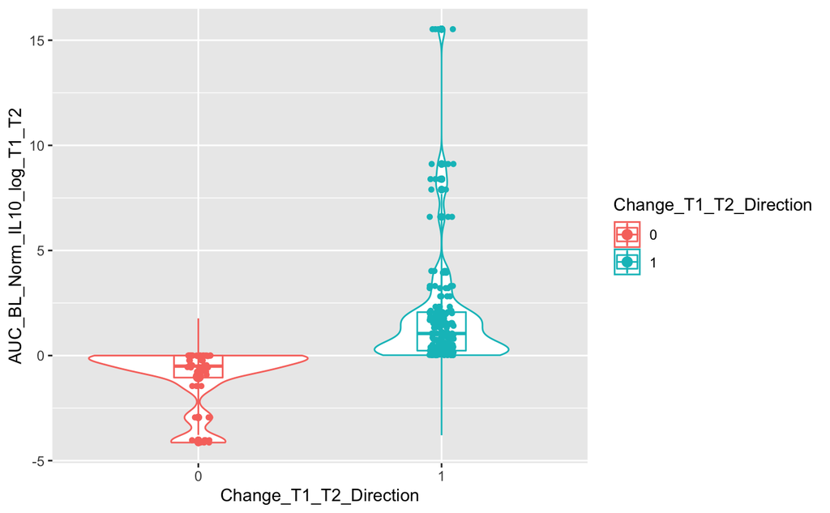

```r
#Calculate the area under the curve between T2 and T3:
AUC_list <- list()
AUC_id <- list()

for (i in unique(SOS_IL10_final$SampleID)) {
    idx <- which(SOS_IL10_final$SampleID==i, arr.ind=TRUE)
    #Get participants AUC for T1-4:
    AUC_list[i] <- auc(
                SOS_IL10_final$Time[idx],
                SOS_IL10_final$BL_Norm_IL10_log[idx],
                from = min(1, na.rm = TRUE),
                to = max(2, na.rm = TRUE),
                type = c("linear"),
                absolutearea = FALSE,
                subdivisions = 100
                )
    #Get SampleID
    AUC_id[i] <- i
}
#Reformat lists into data.frames
AUC_list <- data.frame(AUC_list)
AUC_list <- t(AUC_list)
AUC_list <- data.frame(AUC_list)

AUC_id <- data.frame(AUC_id)
AUC_id <- t(AUC_id)
AUC_id <- data.frame(AUC_id)

#Merge two data.frames
AUC_all <- cbind(AUC_list, AUC_id)

#Clear variables no longer needed:
rm(AUC_list, AUC_id)

#Rename columns for merge (SampleID, also helps for checking that the rows have matched appropriately)
names(AUC_all)[1]<- "AUC_BL_Norm_IL10_log_T1_T2"
names(AUC_all)[2]<- "SampleID"

#Merge with SOS_IL10_final and remove unecessary extra SampleID column:
SOS_IL10_final <-merge(SOS_IL10_final, AUC_all, by = "SampleID", all = TRUE)
rm(AUC_all)

AUC_plot <- ggplot(SOS_IL10_final, aes(Change_T1_T2_Direction, AUC_BL_Norm_IL10_log_T1_T2, colour=Change_T1_T2_Direction)) +
    geom_violin() +
    geom_boxplot(width=0.2, position = "dodge2") +
    stat_summary(fun.data=mean_sdl,
                 geom="pointrange") +
    geom_jitter(shape=16, position=position_jitter(0.05))
AUC_plot
```